# Case_Study_bellabeat

Gustavo Venceslau

2023-11-30

## BELLABEAT use for nutrition plans follow up

This study aims to answer the following questions:

Are users inputting weight data in the app?

How often are they collecting weight data?

Are users using the app as a supportive tool for their nutrition plan or diet?

For this study the weightLogInfo_merged dataframes were used.

## The available Weight data

The graph shows the number of the app users that have input weight data during the period of observation (from 04/12/206 to 05/12/2006).

It seems that users are not using the app for weight control.

The total weight data available comes from eight out of thirty three users.

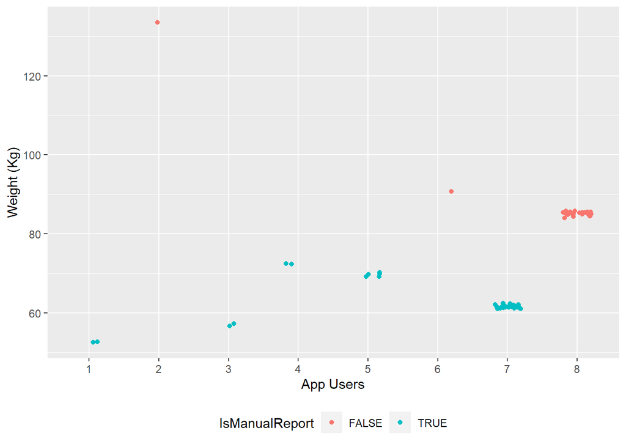

## Detailing user Weight data over time

Few users are consistently inputting weight data over time. Two users have consistently input weight data in the period.

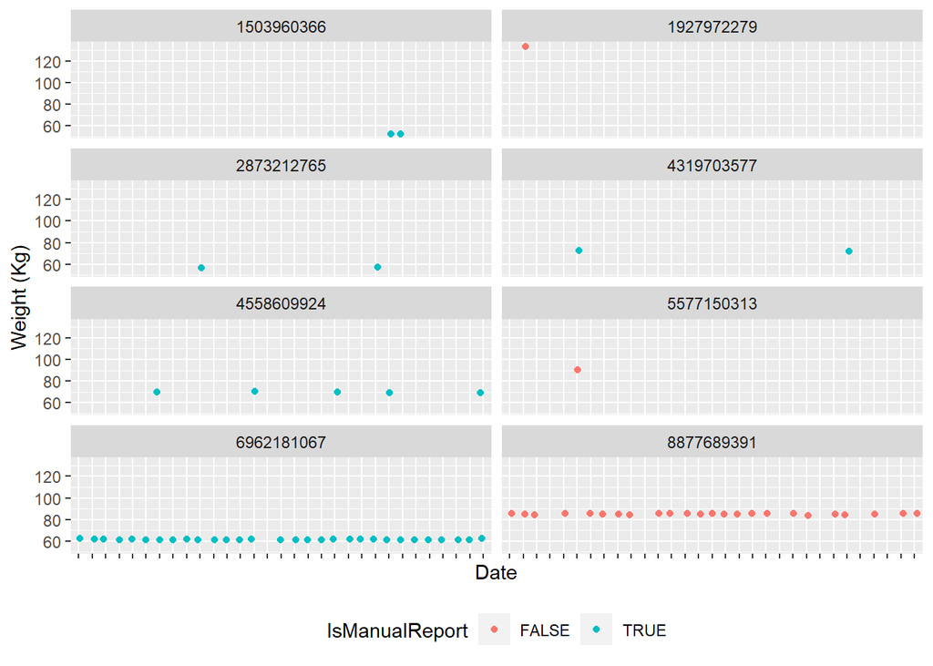

## Facet Ploting Weight data

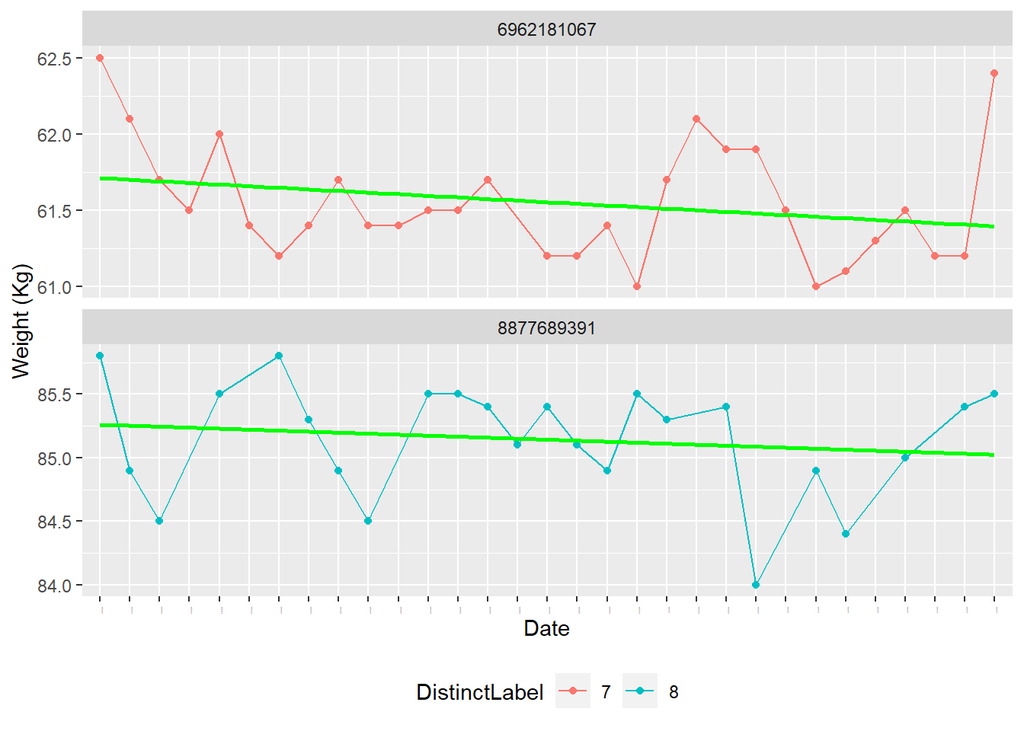

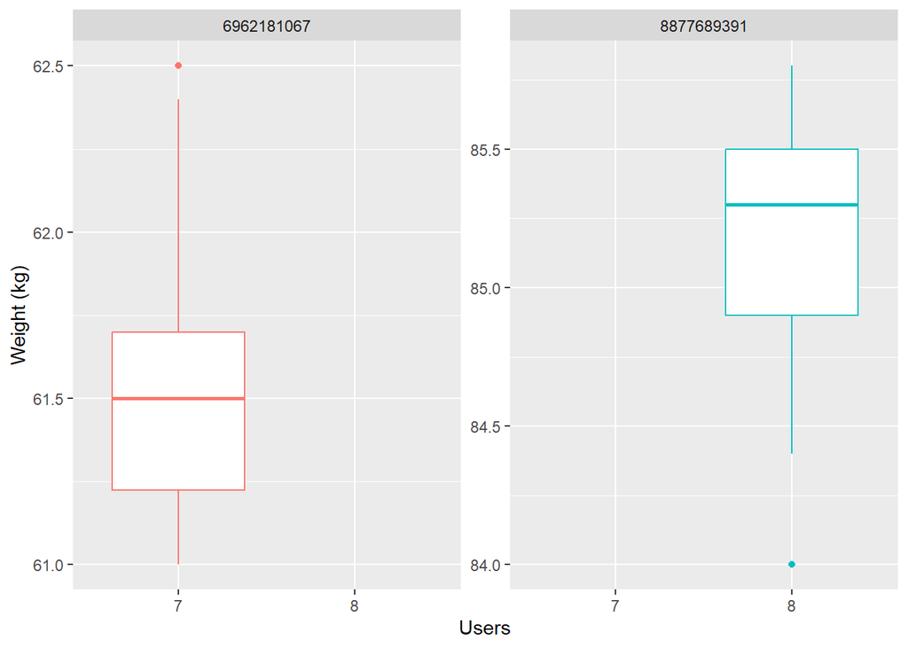

From the previous data and graphs, it is possible to conclude that Bellabeat can expand its use as a weight control tool.

One can think of a slogan: “Bellabeat is your best weight confidence friend!”

:)